# Land a Job Writing R Code

Steve Mortimer  
September 13th, 2017

### About Me

I am a Wahoo!

[figure not shown]

BA Statistics - Dec '09  
MS Statistics - May '11

### About Me

[figure not shown]

**2011-2015**  
Advisory Board Company  
Washington, DC  
*Data Scientist*

[figure not shown]

**2015-2017**  
Homes.com, Inc.  
Norfolk, VA  
*Senior Manager of Data Science*

### I'm Interested In

Actionable

- Accessing New Data Sources (odbc, RForcecom, RSiteCatalyst)
- Creating Webservices with R (opencpu, plumbr)
- Building Web applications (Shiny)
- Production Maching Learning Models (caret, broom, aurelius)

### Disclaimer #1

[figure not shown]

Sorry, I do **NOT** have a job for you.

### I have no job!

[interactive chart not shown]

[via GIPHY](https://giphy.com/gifs/job-couch-unemployment-v7QWfhuS7fDpu)

### Disclaimer #2

This presentation is an adaption of another presentation by Chris Mar ([@cmar](https://twitter.com/cmar)) entitled: “ [The Art of Ruby Technical Interviews](https://www.youtube.com/watch?v=nZNfSQKC-Yk) ”

[video not shown]

### You're Interested in R

[figure not shown]

[figure not shown]

### Pick a Project

Love Shopping?

[figure not shown]

Passion is  
**interesting**

Love Fantasy Football?

[figure not shown]

### Steps to Success

|  | Build It! |
| --- | --- |
|  | Tell Others about it. |
|  | Check it into GitHub. |
|  | Put it on your resume, but one thing… |

### Make a Good README

[figure not shown]

### Know the Community

R is a **Community**

[figure not shown]

> **Interview Tip:** Talk about recent community news.  
> “Hey, what your thoughts on SQL in R Notebooks?”

### Know the Thought Leaders

| Where are they speaking? | What projects are they working on? |
| --- | --- |

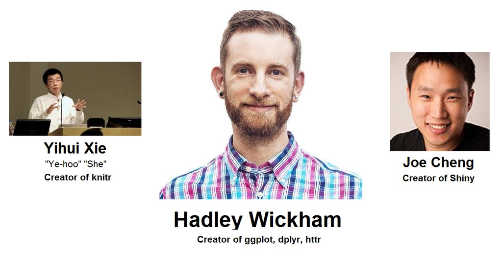

### Know the Conference Lineup

[figure not shown]

### Know the Tools, Packages, etc.

1. Must Know
   - dplyr, ggplot2
2. Should Know
   - knitr, rmarkdown, pander, shiny, httr
3. Nice to Know
   - data.table, doSNOW, testthat, e1071, randomForest, caret

> **Interview Tip:** Have a preference!  
> “I’m open to using tibbles, but right now I like data.table.”

### Commit to Open Source

[figure not shown]

### Even Tiny Contributions are Valid!

[figure not shown]

### Doing the Job Search

Look for R Skills in  
Job Postings

[figure not shown]

Stalk Employees at  
the Company

[figure not shown]

**Tip:** Avoid the technology grab-bag  
(SPSS, SAS, …)

**Tip:** Check them out on social media  
(Twitter, GitHub, …)

### At the Interview

| **①** | Say you are “Proficient” |
| --- | --- |

| Curiousity over Fluency | **②** |
| --- | --- |

| **③** | Work your Angle |
| --- | --- |

### Answering Technical Questions

Do **NOT** say “I could Google it”

[interactive chart not shown]

[via GIPHY](https://giphy.com/gifs/twilight-google-edward-cullen-RJErpbNqZQ652)

### Answering Technical Questions

Do **NOT** be afraid to ask for help

[interactive chart not shown]

[via GIPHY](https://giphy.com/gifs/buzzfeed-unsolved-3-horrifying-cases-of-ghosts-and-demons-3oeHLllK27x6RDyFvq)

### Resources

**R-Users**  
https://www.r-users.com  
**Upwork**  
https://www.upwork.com/o/jobs/browse/skill/r/  
*Backup Resources*  
Indeed  
https://www.indeed.com/q-R-Programmer-jobs.html  
SimplyHired  
http://www.simplyhired.com/search?q=r+programming